# Assignment 1: Data Set Selection, Cleaning, Normalization, and Differential Expression

Mindy Lee

2026-02-11

# 1 Introduction

Idiopathic Pulmonary Fibrosis (IPF) is a chronic and progressive interstitial lung disease defined by irreversible scarring of lung tissue, declining pulmonary function, and poor long-term prognosis. While fibrosis is often described as a problem of extracellular matrix deposition, it is increasingly understood as a systems-level failure of injury response: inflammatory signaling persists, repair programs do not resolve properly, and tissue remodeling becomes self-reinforcing. In this context, immune cells are not merely bystanders—they can help determine whether injury resolves or transitions into pathological fibrosis.

Macrophages are especially relevant to IPF biology because they integrate signals from damaged epithelium, pathogens or irritants, and stromal remodeling. In the lung, macrophage states can shift toward pro-inflammatory or pro-fibrotic phenotypes, influencing cytokine production, growth factor signaling, and extracellular matrix regulation. Therefore, profiling macrophage-rich bronchoalveolar lavage (BAL) samples provides a biologically grounded way to study immune programs that correlate with disease status in human subjects.

In this notebook, I analyze GEO dataset **GSE79544**, a human bulk RNA-seq dataset containing BAL macrophage-rich samples from IPF patients and smoking controls. The goals of this assignment are to (i) obtain the dataset computationally, (ii) assess data quality and overall structure, (iii) map gene identifiers to **unique current HUGO/HGNC symbols**, (iv) clean and normalize the dataset into a reusable expression matrix, and (v) conduct differential expression analysis using a model justified by exploratory plots (MDS/PCA). The final product is a normalized expression matrix with unique HUGO symbols as rownames and numeric expression values in columns, suitable for subsequent assignments (scoring, enrichment, etc.).

# 2 Dataset selection and justification

The dataset **GSE79544** was selected because it satisfies the assignment requirements while also representing an experiment with clear biological meaning. First, the data are derived from **human BAL macrophage-rich samples**, meeting the requirement for human tissue/cell expression data. Second, the experimental comparison is interpretable: IPF patients are contrasted against smoking controls, enabling differential expression in the context of a clinically relevant lung exposure background. Third, the dataset provides RNA-seq counts at gene level, which supports transcriptome-wide coverage rather than targeted measurement. Finally, the sample size (Control n≈7, IPF n≈16 as parsed from metadata) provides biological replication in both groups, making dispersion estimation and downstream modeling feasible.

From an analytical standpoint, this dataset is appropriate for a complete, reproducible workflow: raw counts are available through GEO supplementary files, sample annotations can be obtained through GEOquery, and identifiers can be mapped to current HGNC symbols with a transparent set of rules for handling unmapped and duplicated genes.

# 3 Install packages

```r
pkgs_cran <- c("data.table", "ggplot2", "pheatmap", "R.utils")
pkgs_bioc <- c("GEOquery", "edgeR", "limma", "HGNChelper")

for (p in pkgs_cran) {
  if (!requireNamespace(p, quietly = TRUE)) install.packages(p)
}
if (!requireNamespace("BiocManager", quietly = TRUE)) install.packages("BiocManager")
for (p in pkgs_bioc) {
  if (!requireNamespace(p, quietly = TRUE)) BiocManager::install(p, ask = FALSE)
}

library(GEOquery)
library(data.table)
library(edgeR)
library(limma)
library(ggplot2)
library(pheatmap)
library(HGNChelper)
library(R.utils)
```

# 4 Download data (computational, cached)

This section downloads the GEO Series Matrix (metadata) and the supplementary files containing the count matrix. To avoid re-downloading during repeated knitting, the notebook caches both the metadata object and the extracted count file in the `data/` directory.

```r
gse_id <- "GSE79544"

dir.create("data", showWarnings = FALSE)
dir.create(file.path("data", gse_id), showWarnings = FALSE)
dir.create(file.path("data", gse_id, "supp"), showWarnings = FALSE)

gse_rds  <- file.path("data", gse_id, paste0(gse_id, "_GSEMatrix.rds"))
supp_dir <- file.path("data", gse_id, "supp")

# (1) GEO Series Matrix / metadata (cached)
if (!file.exists(gse_rds)) {
  gse_obj <- GEOquery::getGEO(gse_id, GSEMatrix = TRUE)
  saveRDS(gse_obj, gse_rds)
} else {
  gse_obj <- readRDS(gse_rds)
}

eset  <- gse_obj[[1]]
pheno <- pData(eset)

cat("Metadata samples:", nrow(pheno), "\n")
```

```
## Metadata samples: 23
```

```r
# (2) Supplementary files (cached)
if (length(list.files(supp_dir)) == 0) {
  GEOquery::getGEOSuppFiles(gse_id, baseDir = supp_dir, makeDirectory = FALSE)
}

# Identify a likely counts file.
# If this fails on your machine, print list.files(supp_dir) and adjust patterns.
candidates <- list.files(supp_dir, full.names = TRUE)

# Prefer .txt/.tsv + optional .gz, containing "count" or "counts"
counts_file <- candidates[grepl("count", basename(candidates), ignore.case = TRUE) &
                            grepl("\\.(txt|tsv|csv)(\\.gz)?$", candidates, ignore.case = TRUE)]

if (length(counts_file) != 1) {
  message("Found these potential count files:")
  print(basename(counts_file))
  message("All supplementary files:")
  print(basename(candidates))
  stop("Counts file not uniquely identified. Adjust the pattern above to match the correct file name.")
}

# Unzip if needed
if (grepl("\\.gz$", counts_file, ignore.case = TRUE)) {
  counts_txt <- sub("\\.gz$", "", counts_file, ignore.case = TRUE)
  if (!file.exists(counts_txt)) {
    R.utils::gunzip(counts_file, destname = counts_txt, overwrite = TRUE)
  }
} else {
  counts_txt <- counts_file
}

cat("Using count file:", basename(counts_txt), "\n")
```

```
## Using count file: GSE79544_processed_data_matrix_counts.txt
```

```r
counts_dt <- data.table::fread(counts_txt)
cat("Counts table dims:", paste(dim(counts_dt), collapse = " x "), "\n")
```

```
## Counts table dims: 19723 x 24
```

```r
knitr::kable(
  head(counts_dt[, 1:5]),
  caption = "Table 4.1: Preview of the raw count table (first 6 genes, first 4 samples)."
)
```

Table 4.1: Preview of the raw count table (first 6 genes, first 4 samples).

| Gene | CS1_CTR | CS2_CTR | CS4_CTR | CS5_CTR |
| --- | --- | --- | --- | --- |
| A1BG | 32 | 75 | 51 | 42 |
| A1CF | 1167 | 861 | 1391 | 1259 |
| A2M | 4717 | 5107 | 1140 | 1435 |
| A2ML1 | 339 | 228 | 347 | 355 |
| A3GALT2 | 12 | 12 | 17 | 19 |
| A4GALT | 289 | 226 | 225 | 292 |

**Table 4.1 legend:**  
This table shows a small subset of the raw RNA-seq count matrix as downloaded from GEO supplementary files. Rows correspond to genes (as labeled in the file) and columns correspond to individual RNA-seq libraries (samples). The numeric values are raw read counts prior to filtering and normalization. Because sequencing depth and library composition can vary across samples, these raw counts are not directly comparable between samples without normalization.

# 5 Construct count matrix (required for downstream steps)

The GEO supplementary counts are loaded into a matrix format suitable for RNA-seq modeling. The first column is treated as the gene identifier, and all remaining columns are interpreted as sample count columns.

```r
gene_col <- names(counts_dt)[1]
counts_df <- as.data.frame(counts_dt)

rownames(counts_df) <- counts_df[[gene_col]]
counts_df[[gene_col]] <- NULL

counts_mat <- as.matrix(counts_df)
storage.mode(counts_mat) <- "numeric"

cat("Counts matrix dims:", paste(dim(counts_mat), collapse = " x "), "\n")
```

```
## Counts matrix dims: 19723 x 23
```

# 6 Define conditions (Control vs IPF)

The phenotype metadata is used to define the primary biological factor for analysis: **condition** (Control vs IPF). The rule below is based on pattern matching in the GEO sample titles; this is a transparent and reproducible approach, but it should always be sanity-checked against the GEO record.

```r
pheno$condition <- ifelse(
  grepl("IPF", pheno$title, ignore.case = TRUE), "IPF",
  ifelse(grepl("Control", pheno$title, ignore.case = TRUE), "Control", NA)
)

pheno_clean <- pheno[!is.na(pheno$condition), ]
pheno_clean$condition <- factor(pheno_clean$condition, levels = c("Control", "IPF"))

knitr::kable(
  as.data.frame(table(pheno_clean$condition)),
  col.names = c("Group", "Count"),
  caption = "Table 6.1: Sample counts per condition (Control vs IPF)."
)
```

Table 6.1: Sample counts per condition (Control vs IPF).

| Group | Count |
| --- | --- |
| Control | 7 |
| IPF | 16 |

**Table 6.1 interpretation:**  
This table summarizes the number of biological samples used in each condition after parsing metadata. These group labels define the comparison tested in differential expression analysis. If a sample cannot be confidently assigned, it is excluded rather than guessed.

# 7 Exploratory assessment (QC before normalization)

This section assesses technical variability and overall structure prior to normalization. The goal is not to “judge significance,” but to determine whether samples have consistent depth and comparable distributions.

## 7.1 Library size distribution

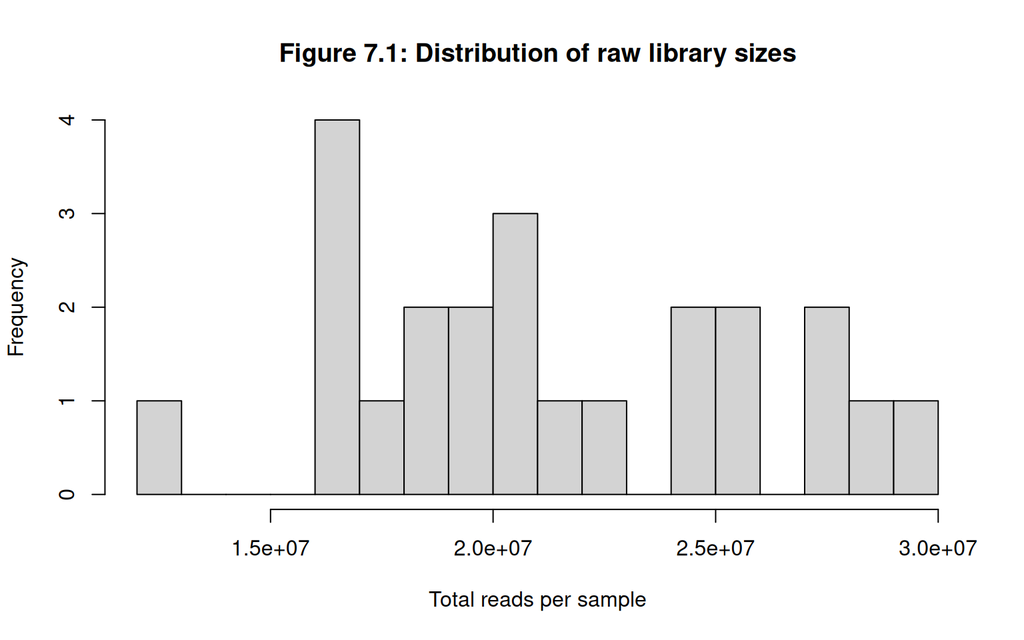

```r
lib_sizes <- colSums(counts_mat)

hist(lib_sizes,
     breaks = 20,
     main = "Figure 7.1: Distribution of raw library sizes",
     xlab = "Total reads per sample")
```

```r
knitr::kable(
  data.frame(
    sample = colnames(counts_mat)[1:min(10, ncol(counts_mat))],
    lib_size = lib_sizes[1:min(10, length(lib_sizes))]
  ),
  caption = "Table 7.1: Raw library sizes (first 10 samples)."
)
```

Table 7.1: Raw library sizes (first 10 samples).

|  | sample | lib_size |
| --- | --- | --- |
| CS1_CTR | CS1_CTR | 24526865 |
| CS2_CTR | CS2_CTR | 29008610 |
| CS4_CTR | CS4_CTR | 20083047 |
| CS5_CTR | CS5_CTR | 22703311 |
| CS23_CTR | CS23_CTR | 16079042 |
| CS24_CTR | CS24_CTR | 16642873 |
| CS25_CTR | CS25_CTR | 12152411 |
| CS3_IPF | CS3_IPF | 25715084 |
| CS7_IPF | CS7_IPF | 24556211 |
| CS8_IPF | CS8_IPF | 20922009 |

**Figure 7.1 legend:**  
Histogram of raw library sizes (total reads per sample). Variation is expected in RNA-seq, but substantial differences motivate normalization to ensure that observed expression differences reflect biology rather than sequencing depth.

## 7.2 Density plot of log2 raw counts

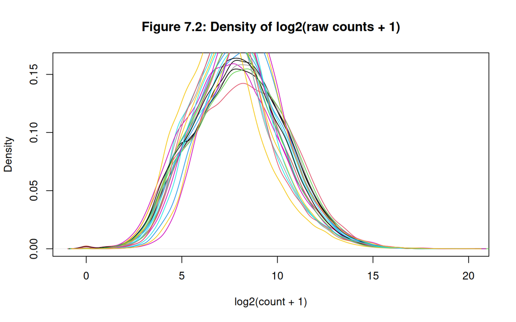

```r
log_raw <- log2(counts_mat + 1)

plot(density(log_raw[, 1]),
     main = "Figure 7.2: Density of log2(raw counts + 1)",
     xlab = "log2(count + 1)")

for (i in 2:ncol(log_raw)) {
  lines(density(log_raw[, i]), col = i)
}
```

**Figure 7.2 legend:**  
Density curves of log2-transformed raw counts across samples. Misalignment between curves suggests differences in library composition and depth. Normalization aims to reduce these technical differences while preserving true biological signal.

# 8 Map to current HUGO/HGNC symbols (Map + Clean)

RNA-seq count matrices can include outdated gene symbols, aliases, or identifiers that are not current HUGO symbols. To ensure that the final dataset is compatible with downstream annotation and pathway analysis, gene identifiers are cleaned using **HGNChelper**. The rules below are explicit: if HGNChelper suggests a current symbol, it is used; otherwise the original label is retained. Unmappable/empty symbols are removed. Duplicate symbols are collapsed by summing counts, producing one row per unique symbol.

```r
mapped <- HGNChelper::checkGeneSymbols(rownames(counts_mat))

new_sym <- ifelse(
  is.na(mapped$Suggested.Symbol) | mapped$Suggested.Symbol == "",
  mapped$x,
  mapped$Suggested.Symbol
)

rownames(counts_mat) <- new_sym

before_unmapped <- nrow(counts_mat)
counts_mat <- counts_mat[rownames(counts_mat) != "" & !is.na(rownames(counts_mat)), , drop = FALSE]
after_unmapped <- nrow(counts_mat)

dup_before <- nrow(counts_mat)
counts_mat <- rowsum(counts_mat, group = rownames(counts_mat))
dup_after <- nrow(counts_mat)

cat("Rows removed due to unmapped/empty symbols:", before_unmapped - after_unmapped, "\n")
```

```
## Rows removed due to unmapped/empty symbols: 0
```

```r
cat("Rows collapsed due to duplicates:", dup_before - dup_after, "\n")
```

```
## Rows collapsed due to duplicates: 43
```

```r
cat("Post-HGNC cleanup dims:", paste(dim(counts_mat), collapse = " x "), "\n")
```

```
## Post-HGNC cleanup dims: 19680 x 23
```

**Interpretation (mapping + duplicates):**  
Rows that could not be associated with a valid gene symbol (empty/NA after cleanup) were removed to prevent ambiguous identifiers from propagating into downstream steps. Multiple rows mapping to the same symbol were collapsed by summation because counts are additive across fragments/probes targeting the same gene. This results in a final expression set with unique gene symbols as rownames, satisfying the assignment specification.

# 9 Filtering and normalization

## 9.1 Why filtering?

Very lowly expressed genes contribute little statistical power while inflating the multiple-testing burden. Filtering reduces noise and improves the reliability of variance estimation.

## 9.2 Why TMM normalization?

TMM (Trimmed Mean of M-values) is widely used for RNA-seq because it corrects for library composition bias, where a subset of highly expressed genes can distort scaling. TMM is robust in differential expression settings where genuine biological shifts exist (Robinson & Oshlack, 2010).

```r
# Ensure column names exist and match samples
if (is.null(colnames(counts_mat)) || any(colnames(counts_mat) == "")) {
  colnames(counts_mat) <- pheno_clean$geo_accession
}
stopifnot(ncol(counts_mat) == nrow(pheno_clean))

dge <- DGEList(counts = counts_mat, group = pheno_clean$condition)

keep <- filterByExpr(dge, group = pheno_clean$condition)
dge <- dge[keep, , keep.lib.sizes = FALSE]
cat("Genes kept after filtering:", nrow(dge), "\n")
```

```
## Genes kept after filtering: 19561
```

```r
dge <- calcNormFactors(dge, method = "TMM")
logcpm <- cpm(dge, log = TRUE, prior.count = 2)

lib_tab <- data.frame(
  sample = colnames(dge),
  lib_size = dge$samples$lib.size,
  norm_factor = dge$samples$norm.factors,
  condition = pheno_clean$condition
)

knitr::kable(head(lib_tab, 10),
             caption = "Table 9.1: Library sizes and TMM normalization factors (first 10 samples).")
```

Table 9.1: Library sizes and TMM normalization factors (first 10 samples).

[output not shown]

## 9.3 Pre vs post normalization plots

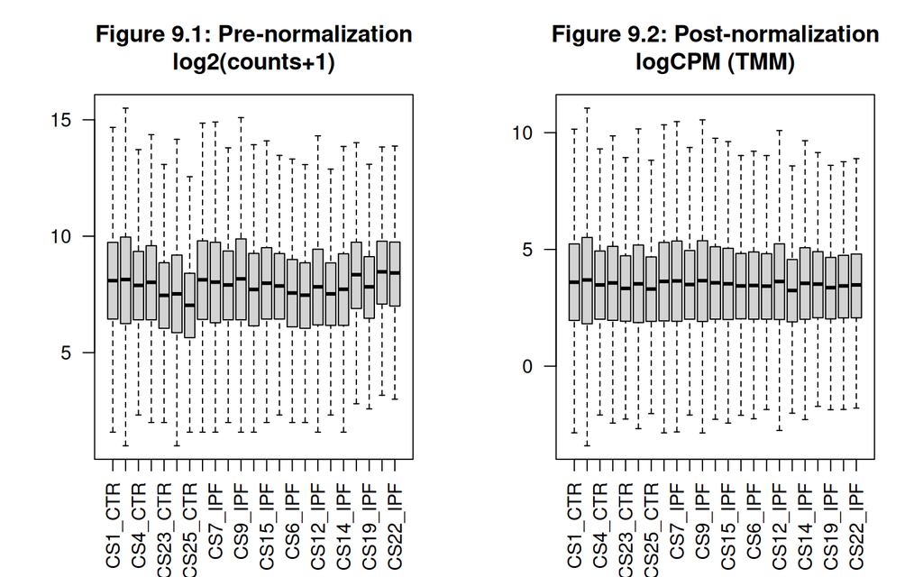

```r
par(mfrow = c(1,2))

boxplot(log2(dge$counts + 1),
        main = "Figure 9.1: Pre-normalization\nlog2(counts+1)",
        outline = FALSE,
        las = 2)

boxplot(logcpm,
        main = "Figure 9.2: Post-normalization\nlogCPM (TMM)",
        outline = FALSE,
        las = 2)
```

```r
par(mfrow = c(1,1))
```

**Figure 9.1–9.2 legend:**  
Boxplots summarize sample-wise expression distributions before and after normalization. After TMM normalization (logCPM), distributions are more comparable across samples, supporting reduced technical variability.

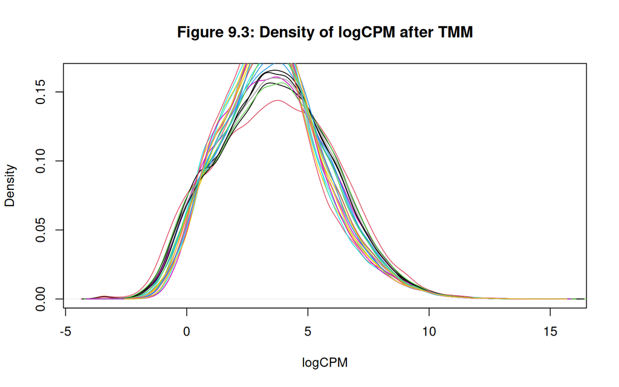

```r
plot(density(logcpm[,1]),
     main="Figure 9.3: Density of logCPM after TMM",
     xlab="logCPM")

for(i in 2:ncol(logcpm)){
  lines(density(logcpm[,i]), col=i)
}
```

**Figure 9.3 legend:**  
Density curves of normalized logCPM values. Improved alignment across samples indicates that normalization has reduced library-driven differences while preserving variation needed for biological comparisons.

# 10 Structure and outlier assessment (MDS + PCA)

Exploratory ordination methods provide a global view of whether samples cluster by condition and whether any samples appear inconsistent with their labels.

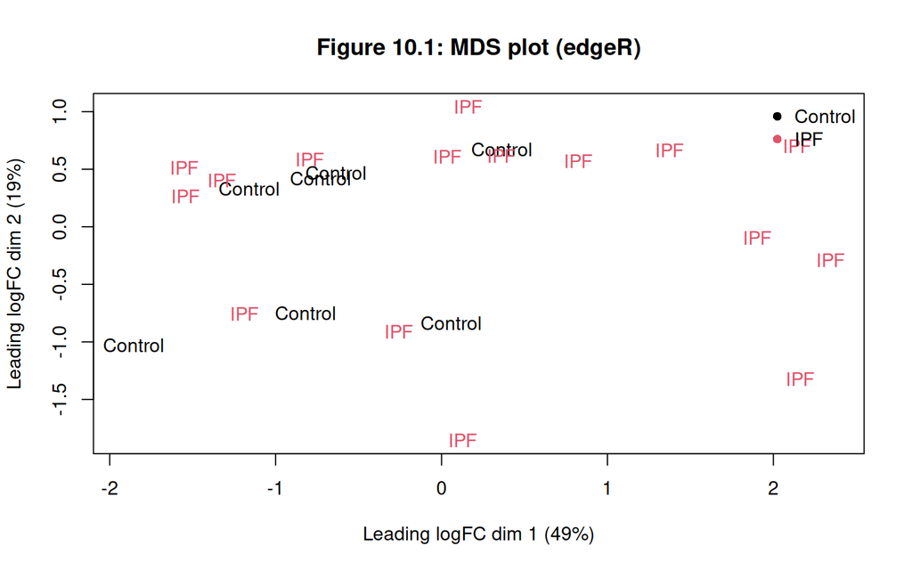

```r
plotMDS(dge,
        labels = pheno_clean$condition,
        col = as.integer(pheno_clean$condition))
title("Figure 10.1: MDS plot (edgeR)")

legend("topright",
       legend = levels(pheno_clean$condition),
       col = 1:length(levels(pheno_clean$condition)),
       pch = 16,
       bty = "n")
```

**Figure 10.1 legend:**  
MDS summarizes sample-to-sample distances based on expression profiles. Separation between IPF and Control suggests condition-driven structure. Samples that fall far from their group would be investigated as potential outliers.

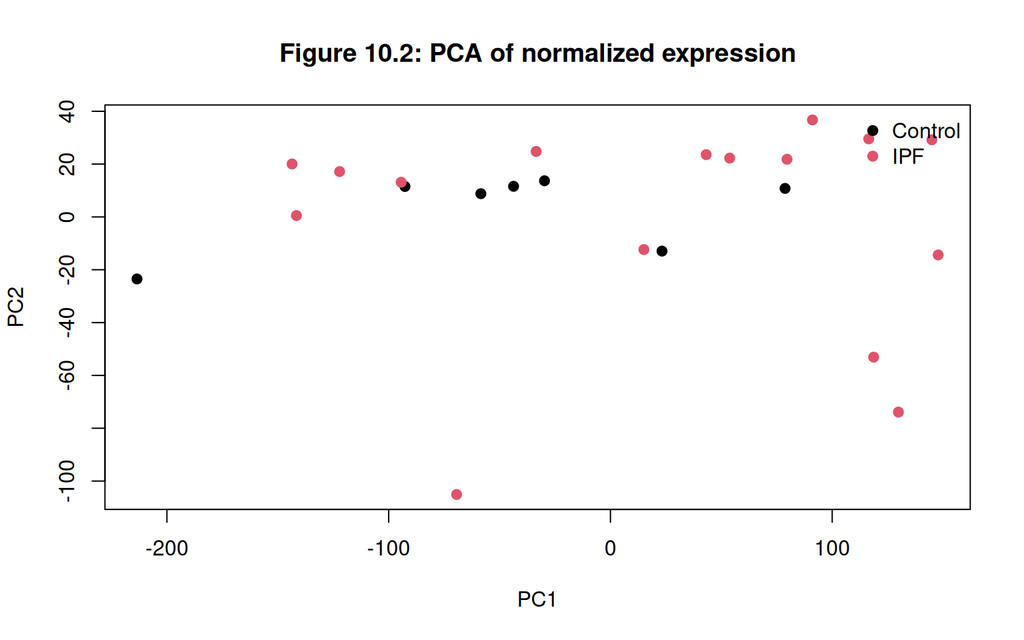

```r
pca <- prcomp(t(logcpm), scale. = TRUE)

plot(pca$x[,1], pca$x[,2],
     col = as.integer(pheno_clean$condition),
     pch = 19,
     xlab = "PC1",
     ylab = "PC2",
     main = "Figure 10.2: PCA of normalized expression")

legend("topright",
       legend = levels(pheno_clean$condition),
       col = 1:length(levels(pheno_clean$condition)),
       pch = 19,
       bty = "n")
```

**Figure 10.2 legend:**  
PCA displays major axes of variability in the normalized dataset. If IPF vs Control separates along early PCs, this supports that disease status explains a meaningful fraction of expression variance.

**Outliers removed (explicit answer):**  
No samples were removed automatically. Outlier removal is only justified if there is evidence of technical error or mislabeling; otherwise biological heterogeneity is expected in human patient cohorts.

# 11 Differential expression analysis (limma-voom)

Because RNA-seq count data exhibit a mean–variance relationship, limma-voom is used to estimate precision weights and enable linear modeling with empirical Bayes moderation. This approach is well-established for RNA-seq differential expression and performs reliably with moderate sample sizes.

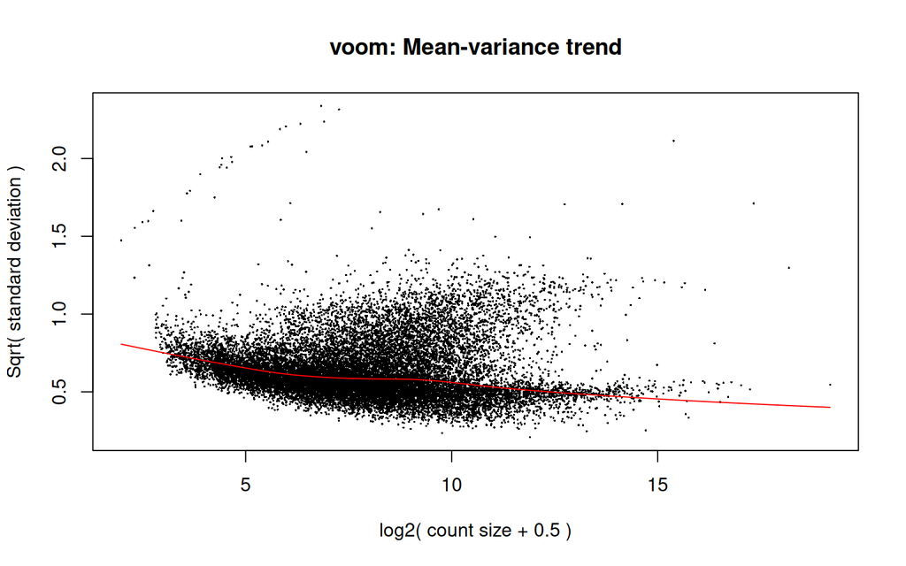

```r
design <- model.matrix(~ 0 + pheno_clean$condition)
colnames(design) <- levels(pheno_clean$condition)

v <- voom(dge, design, plot = TRUE)
```

```r
fit <- lmFit(v, design)
cont <- makeContrasts(IPFvsControl = IPF - Control, levels = design)
fit2 <- eBayes(contrasts.fit(fit, cont))

tt <- topTable(fit2, number = Inf, sort.by = "P")
tt$gene <- rownames(tt)

knitr::kable(head(tt, 10),
             caption = "Table 11.1: Top 10 differentially expressed genes (IPF vs Control).")
```

Table 11.1: Top 10 differentially expressed genes (IPF vs Control).

|  | logFC | AveExpr | t | P.Value | adj.P.Val | B | gene |
| --- | --- | --- | --- | --- | --- | --- | --- |
| LYPD2 | 1.0308989 | -1.1592762 | 5.306920 | 0.0000197 | 0.3850011 | -3.596355 | LYPD2 |
| ASPM | 0.3458718 | 4.5702981 | 4.300770 | 0.0002499 | 0.4504792 | -2.752952 | ASPM |
| OR51B6 | 0.7401315 | 0.0577841 | 4.250886 | 0.0002835 | 0.4504792 | -3.538856 | OR51B6 |
| EPS8 | 0.3508858 | 3.9682961 | 4.225444 | 0.0003024 | 0.4504792 | -2.815462 | EPS8 |
| OR6C4 | 0.9686694 | -0.2231609 | 4.151039 | 0.0003650 | 0.4504792 | -3.658261 | OR6C4 |
| OR5P2 | 0.9166120 | -0.0156948 | 4.031417 | 0.0004935 | 0.4504792 | -3.644704 | OR5P2 |
| METTL9 | -0.8686318 | 3.8240690 | -3.957296 | 0.0005948 | 0.4504792 | -2.969621 | METTL9 |
| ENPP5 | 0.4311709 | 3.7879486 | 3.951906 | 0.0006029 | 0.4504792 | -2.984494 | ENPP5 |
| OR51V1 | 0.6729774 | 0.2644740 | 3.932194 | 0.0006335 | 0.4504792 | -3.593579 | OR51V1 |
| ARPP21 | 0.6075719 | 4.4764005 | 3.881968 | 0.0007186 | 0.4504792 | -3.008154 | ARPP21 |

**Voom plot legend:**  
The voom mean–variance plot visualizes the dependence of variance on mean expression and the fitted trend used to compute observation-level weights. This step enables appropriate linear modeling of RNA-seq derived expression values.

# 12 Significance thresholds and multiple testing (explicit)

To define a practical and interpretable set of differential expression hits, I used two criteria: statistical significance after multiple testing correction and a minimum effect size. Specifically:

- **FDR < 0.05** using the Benjamini–Hochberg procedure
- **|log2 fold-change| ≥ 1** to focus on changes of at least ~2-fold

FDR control is necessary because thousands of genes are tested simultaneously; without correction, many low p-values would occur by chance (Benjamini & Hochberg, 1995).

```r
tt$signif <- tt$adj.P.Val < 0.05 & abs(tt$logFC) >= 1
cat("DE genes (FDR<0.05 & |logFC|>=1):", sum(tt$signif), "\n")
```

```
## DE genes (FDR<0.05 & |logFC|>=1): 0
```

# 13 Visualizations (Volcano, MA, Heatmap)

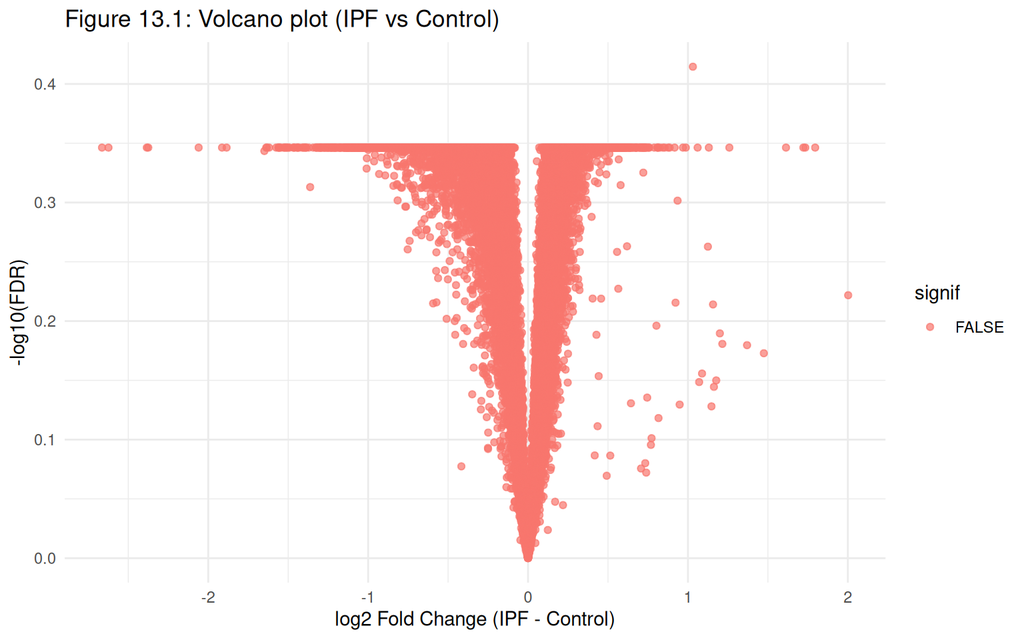

```r
ggplot(tt, aes(x = logFC, y = -log10(adj.P.Val))) +
  geom_point(aes(color = signif), alpha = 0.7) +
  theme_minimal() +
  labs(
    title = "Figure 13.1: Volcano plot (IPF vs Control)",
    x = "log2 Fold Change (IPF - Control)",
    y = "-log10(FDR)"
  )
```

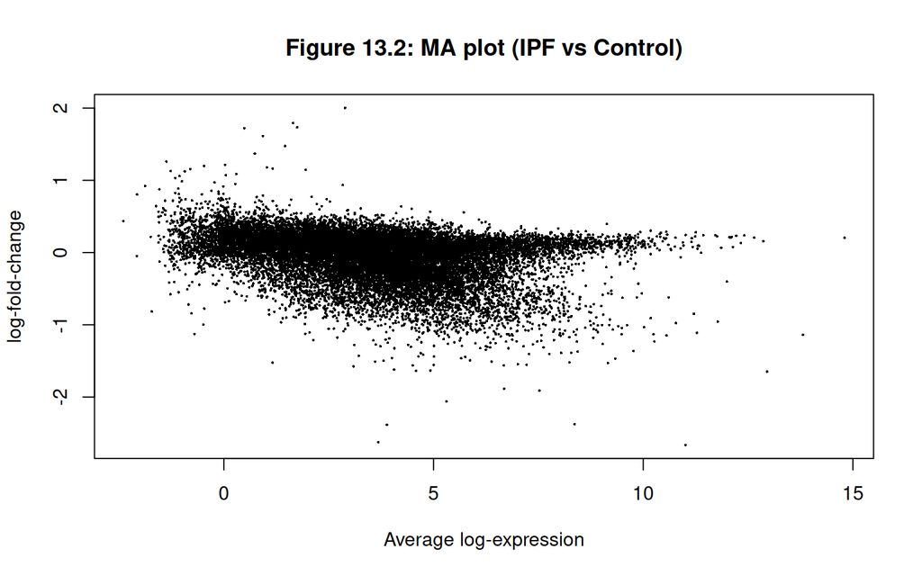

```r
plotMA(fit2, main = "Figure 13.2: MA plot (IPF vs Control)")
```

**Figure 13.2 legend:**  
MA plot shows log fold-change versus average expression. It helps assess whether differential expression is concentrated in low-expression genes and provides a complementary view to the volcano plot.

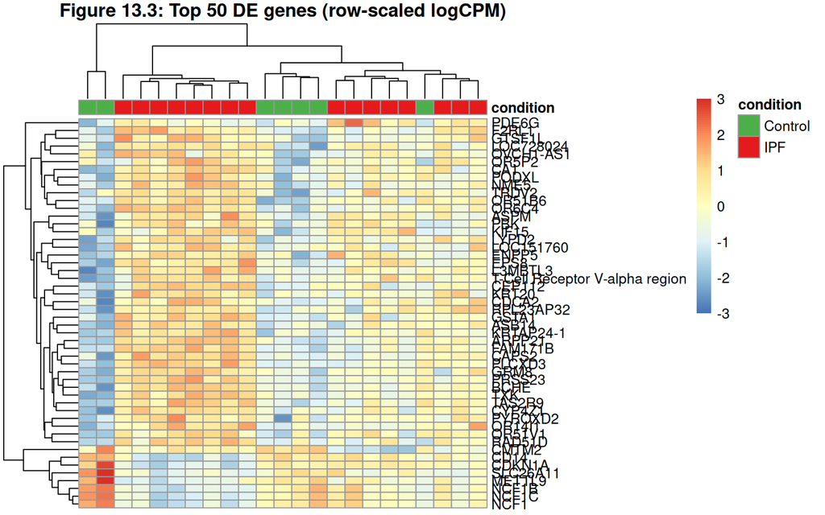

```r
# pick top genes safely
top50 <- tt$gene[order(tt$adj.P.Val)][1:50]
mat_top <- logcpm[top50, , drop = FALSE]

# Build annotation_col with rownames matching the matrix columns
annotation_col <- data.frame(condition = pheno_clean$condition)
rownames(annotation_col) <- colnames(mat_top)

# Ensure condition is a factor with correct levels
annotation_col$condition <- factor(annotation_col$condition, levels = c("Control", "IPF"))

# Provide explicit colors for annotation to avoid 'fill length 0' errors
annotation_colors <- list(
  condition = c(Control = "#4DAF4A", IPF = "#E41A1C")
)

pheatmap::pheatmap(
  mat_top,
  scale = "row",
  annotation_col = annotation_col,
  annotation_colors = annotation_colors,
  show_colnames = FALSE,
  main = "Figure 13.3: Top 50 DE genes (row-scaled logCPM)"
)
```